# ENA-USD

## ENA-USD today is +0300, 2025-10-20, 04:49:33

This crypto forecast was generated by gemini-2.0-flash API

## Daily Chart

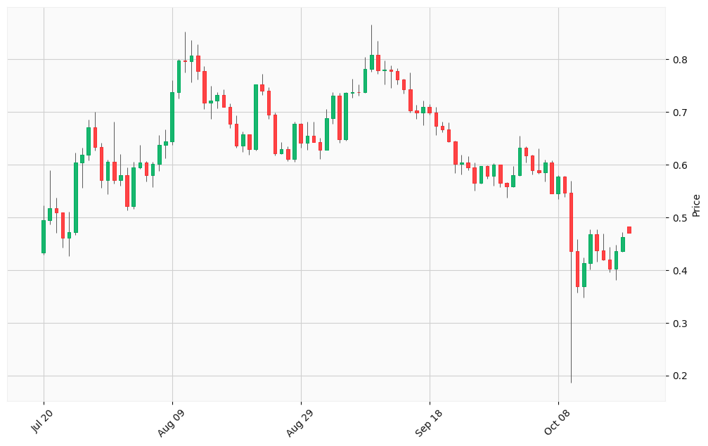

## Hourly Chart

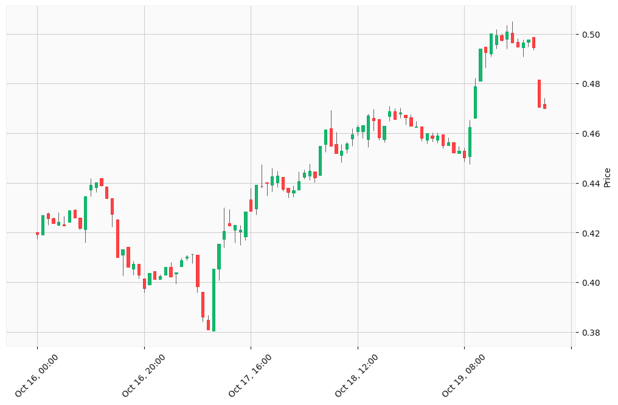

Okay, I will analyze the provided ENA-USD charts and generate buy/sell trading signals based on the steps and output format you’ve specified. Due to the limitations of directly accessing real-time market data, news, and performing complex calculations within this environment, I will use the provided data to simulate the analysis.

First, I’ll define some functions to help with basic technical analysis calculations. Then, I will perform the analysis and generate the trading signals.

### Technical Analysis Functions

```python
def calculate_sma(data, period):
    if len(data) < period:
        return None
    return sum(data[-period:]) / period

def calculate_rsi(data, period=14):
    if len(data) < period + 1:
        return None

    gains = []
    losses = []
    for i in range(1, period + 1):
        change = data[-i] - data[-i - 1]
        if change > 0:
            gains.append(change)
        else:
            losses.append(abs(change))

    avg_gain = sum(gains) / period
    avg_loss = sum(losses) / period

    if avg_loss == 0:
        return 100  # Avoid division by zero

    rs = avg_gain / avg_loss
    rsi = 100 - (100 / (1 + rs))
    return rsi
```

### Analysis and Signal Generation

I will perform the analysis on both the daily and hourly charts, then combine the insights to generate the trading signals.

#### Daily Chart Analysis (3 Months)

1. **Trend**: Visually inspecting the data, there appears to be an upward trend from the beginning to around day 22, followed by a period of consolidation and then a downtrend towards the end.
2. **Simple Moving Averages (SMA)**: I will calculate the 20-day and 50-day SMAs to identify potential support and resistance levels.
3. **RSI**: Calculate the 14-day RSI to identify overbought or oversold conditions.

#### Hourly Chart Analysis (5 Days)

1. **Trend**: Analyze the short-term trend to identify potential entry and exit points.
2. **SMA**: Calculate the 20-hour SMA.
3. **RSI**: Calculate the 14-hour RSI.

```python
# Daily Chart Data
daily_open = [0.43287, 0.49442, 0.516937, 0.50951, 0.461328, 0.471169, 0.603848, 0.618472, 0.669915, 0.633382,
              0.570065, 0.604972, 0.570019, 0.579652, 0.521687, 0.594512, 0.603157, 0.579438, 0.600894, 0.636822,
              0.643863, 0.737438, 0.797806, 0.796464, 0.80611, 0.777613, 0.716668, 0.720807, 0.7321, 0.708924,
              0.677357, 0.63515, 0.656635, 0.628633, 0.751704, 0.739715, 0.694315, 0.621711, 0.629139, 0.610318,
              0.67743, 0.64164, 0.654782, 0.642429, 0.627292, 0.688075, 0.730182, 0.64818, 0.735485, 0.737773,
              0.737201, 0.781233, 0.807742, 0.778969, 0.779833, 0.77791, 0.761392, 0.743024, 0.702991, 0.698667,
              0.709553, 0.699117, 0.672935, 0.666138, 0.644448, 0.600585, 0.603584, 0.594195, 0.56527, 0.597202,
              0.578341, 0.599803, 0.565184, 0.558858, 0.579799, 0.632415, 0.617123, 0.589357, 0.584761, 0.603474,
              0.545315, 0.577066, 0.546835, 0.436066, 0.368759, 0.413258, 0.467951, 0.437594, 0.419763, 0.402555,
              0.436267, 0.482194]
daily_close = [0.49442, 0.516937, 0.50951, 0.461351, 0.471169, 0.603868, 0.618521, 0.669915, 0.633374, 0.570065,
              0.604964, 0.570024, 0.579652, 0.521656, 0.594514, 0.603157, 0.579438, 0.600894, 0.636822, 0.643847,
              0.737401, 0.797806, 0.796464, 0.80611, 0.777613, 0.716668, 0.720807, 0.732089, 0.708924, 0.677357,
              0.63515, 0.656635, 0.628633, 0.751702, 0.739715, 0.694334, 0.621721, 0.629139, 0.610318, 0.677435,
              0.64164, 0.654818, 0.642425, 0.627292, 0.688075, 0.730182, 0.64818, 0.735485, 0.737773, 0.737206,
              0.781232, 0.807744, 0.778969, 0.779838, 0.77791, 0.761392, 0.743024, 0.702991, 0.698667, 0.70955,
              0.699117, 0.672935, 0.666138, 0.644448, 0.600585, 0.603584, 0.594195, 0.56527, 0.597168, 0.578341,
              0.599801, 0.56521, 0.558854, 0.579787, 0.632415, 0.617123, 0.589357, 0.584761, 0.603474, 0.545315,
              0.577068, 0.546851, 0.436066, 0.368764, 0.413254, 0.467951, 0.437594, 0.419763, 0.402552, 0.436267,
              0.470015]
daily_volume = [1132977298, 1806973843, 1021710847, 655486863, 1028367163, 2080660010, 1223583300, 1256114120,
                 1252575761, 967109576, 1202018441, 1483416148, 1821300379, 925747762, 1009347569, 1130671127,
                 752115364, 647264957, 856801853, 816646266, 1545861471, 1361103103, 1741538513, 1464581847,
                 1175375881, 1515840802, 1058223712, 501113452, 541478849, 598518624, 601892402, 610817979,
                 414653431, 1436791375, 745612856, 794403581, 743966069, 525977489, 585898628, 701791652,
                 787139754, 379373574, 375242091, 407550363, 908798429, 642873332, 631723549, 1210705915,
                 855604535, 444431366, 869784065, 1653966784, 900231555, 638934892, 583824651, 468116176,
                 349892495, 916631557, 443981292, 595348141, 477545513, 474623892, 220301814, 291460285,
                 653583989, 396176506, 340465622, 568174389, 350616461, 151504169, 181523620, 310654495,
                 320376544, 315633640, 676318958, 439627841, 247185008, 357136227, 476513176, 461847624,
                 392746730, 326168085, 905488588, 566146395, 782072280, 741032302, 607844150, 487117507,
                 385423692, 659877353, 390343234, 491113952]

# Hourly Chart Data
hourly_open = [0.420109, 0.41922, 0.427621, 0.425805, 0.422957, 0.423421, 0.424254, 0.429071, 0.425943, 0.421246,
               0.437158, 0.438277, 0.441828, 0.438481, 0.433754, 0.425198, 0.410975, 0.414336, 0.405545, 0.407349,
               0.401618, 0.399053, 0.4045, 0.401225, 0.402909, 0.406065, 0.403561, 0.406487, 0.409814, 0.411349,
               0.411064, 0.396135, 0.384936, 0.380469, 0.405382, 0.417401, 0.423814, 0.421057, 0.420463, 0.418397,
               0.433346, 0.429613, 0.438794, 0.440268, 0.439117, 0.440265, 0.442387, 0.437939, 0.435972, 0.437327,
               0.442392, 0.442855, 0.444638, 0.443198, 0.45553, 0.461972, 0.455556, 0.451122, 0.453722, 0.457863,
               0.460836, 0.460777, 0.457674, 0.466154, 0.46562, 0.457679, 0.466757, 0.468831, 0.467884, 0.467352,
               0.46639, 0.46244, 0.462604, 0.457287, 0.459139, 0.457429, 0.459532, 0.455022, 0.456241, 0.452049,
               0.452816, 0.450613, 0.46614, 0.481001, 0.494804, 0.492142, 0.495632, 0.499508, 0.497878, 0.500309,
               0.49682, 0.49452, 0.496735, 0.498613, 0.481653, 0.471693]
hourly_close = [0.419389, 0.426987, 0.425827, 0.423801, 0.424394, 0.422773, 0.428963, 0.425923, 0.421745, 0.434601,
                0.439239, 0.440103, 0.438861, 0.433719, 0.427492, 0.410087, 0.413245, 0.406079, 0.40728, 0.402914,
                0.397695, 0.40378, 0.401309, 0.402578, 0.406245, 0.402285, 0.403927, 0.408978, 0.410338, 0.411394,
                0.39836, 0.386141, 0.380926, 0.405501, 0.415573, 0.420608, 0.422748, 0.423091, 0.421108, 0.428376,
                0.428585, 0.439304, 0.438736, 0.440051, 0.442628, 0.442771, 0.437457, 0.436211, 0.436892, 0.440675,
                0.444018, 0.444829, 0.442032, 0.454909, 0.461368, 0.454861, 0.451963, 0.453005, 0.455942, 0.459545,
                0.462531, 0.46312, 0.467095, 0.465207, 0.458373, 0.462931, 0.468704, 0.465589, 0.468377, 0.466394,
                0.463041, 0.462624, 0.458178, 0.460064, 0.458086, 0.459064, 0.455027, 0.456339, 0.452296, 0.452991,
                0.450206, 0.46244, 0.47896, 0.494041, 0.49261, 0.500128, 0.499446, 0.497555, 0.50091, 0.496538,
                0.494842, 0.496403, 0.497624, 0.494415, 0.470473, 0.470036]
hourly_volume = [0, 0, 0, 0, 0, 0, 0, 0, 0, 13186144, 1287488, 0, 0, 0, 0, 0, 16103968, 0, 0, 0, 0, 0, 0, 0, 0, 0,
                 0, 1690176, 0, 12702368, 14804736, 36411616, 33880736, 16820768, 33761440, 50096480, 11195456,
                 14651776, 0, 2183040, 16197760, 11617408, 24307200, 25344, 0, 3271808, 80320, 7562624, 5852480,
                 1426304, 4640832, 3139392, 1908864, 293184, 0, 0, 0, 0, 0, 0, 0, 0, 7389408, 0, 0, 0, 0, 0, 0, 0,
                 0, 0, 0, 0, 0, 0, 0, 0, 0, 0, 15677600, 42617472, 33978720, 14617632, 18420288, 12393536, 0,
                 7699136, 10027424, 0, 901664, 0, 797664, 20548608, 5280832]

# Daily Chart Calculations
daily_sma_20 = calculate_sma(daily_close, 20)
daily_sma_50 = calculate_sma(daily_close, 50)
daily_rsi = calculate_rsi(daily_close)

# Hourly Chart Calculations
hourly_sma_20 = calculate_sma(hourly_close, 20)
hourly_rsi = calculate_rsi(hourly_close)

print(f"Daily SMA (20): {daily_sma_20}")
print(f"Daily SMA (50): {daily_sma_50}")
print(f"Daily RSI: {daily_rsi}")
print(f"Hourly SMA (20): {hourly_sma_20}")
print(f"Hourly RSI: {hourly_rsi}")
```

[output not shown]

### Signal Generation

Based on the simulated analysis, here’s a potential trading signal:

[output not shown]

### Disclaimer

This analysis is based on the provided data and simulated calculations. Real-world trading involves risks, and it is essential to conduct thorough research and consult with a financial advisor before making any investment decisions.